# NYPD Shootings Analysis

2026-02-23

## NYC shootings data

This report analyzes shootings in the City of New York from 2006 to 2025. Data is sourced from the [Data.gov City of New York collection](https://catalog.data.gov/dataset/nypd-shootings/resource/e8892e88-ff68-4886-b0ab-190263861d38). Time-series and spatial analyses will be created.

**Be aware that for this document to work, the following packages *must* be installed:**

- tidyverse
- tidymodels
- nycgeo
- sf

The two geo packages can be somewhat tricky to install. If you don´t have them working, remove the choropleth section in `Where do shootings happen?`.

```r
library(tidyverse)
library(lubridate)
library(tidymodels)

url.historic <- "https://data.cityofnewyork.us/api/views/5ucz-vwe8/rows.csv?accessType=DOWNLOAD"

shootings.incidents <- read_csv(url.historic) %>% distinct(INCIDENT_KEY, .keep_all = TRUE)
```

Let’s clean the data. For this analysis, we’ll focus on temporal and spatial variables: the date and time of the shooting, the borough and precinct it occurred in, and the type of location of the incident.

```r
cols.to.keep <- c("OCCUR_DATE", "OCCUR_TIME", "BORO", "LOC_OF_OCCUR_DESC", "PRECINCT", "LOC_CLASSFCTN_DESC")
shootings.clean <- shootings.incidents %>%
  select(all_of(cols.to.keep)) %>%
  transmute(
    Date = as.Date(OCCUR_DATE, format = "%m/%d/%Y"),
    Hour.of.day = hour(OCCUR_TIME),
    Borough = as.factor(BORO),
    Precinct = as.character(PRECINCT),
    Location = as.factor(LOC_OF_OCCUR_DESC),
    Location.type = as.factor(LOC_CLASSFCTN_DESC)
    )

summary(shootings.clean)
```

```
##       Date             Hour.of.day             Borough       Precinct
##  Min.   :2006-01-01   Min.   : 0.00   BRONX        :6925   Length:23988
##  1st Qu.:2010-01-19   1st Qu.: 3.00   BROOKLYN     :9677   Class :character
##  Median :2014-07-13   Median :15.00   MANHATTAN    :3145   Mode  :character
##  Mean   :2015-02-26   Mean   :12.34   QUEENS       :3570
##  3rd Qu.:2020-08-24   3rd Qu.:20.00   STATEN ISLAND: 671
##  Max.   :2025-12-31   Max.   :23.00
##
##     Location        Location.type
##  INSIDE : 3392   STREET    :15681
##  OUTSIDE:20596   HOUSING   : 4446
##                  DWELLING  : 1938
##                  COMMERCIAL: 1007
##                  PLAYGROUND:  284
##                  (Other)   :  600
##                  NA's      :   32
```

## Shootings over time

Plotting the shooting incidents over time illustrates three interesting trends in the shootings, at different levels of time granularity:

1. A broad downward secular trend in gun violence. Later years, speaking generally, had less violence than earlier ones.
2. A spike in gun violence as the COVID-19 pandemic hit NYC in mid-2020.
3. A yearly cyclical trend, in which there is more gun violence in the summers, and less in the winters.

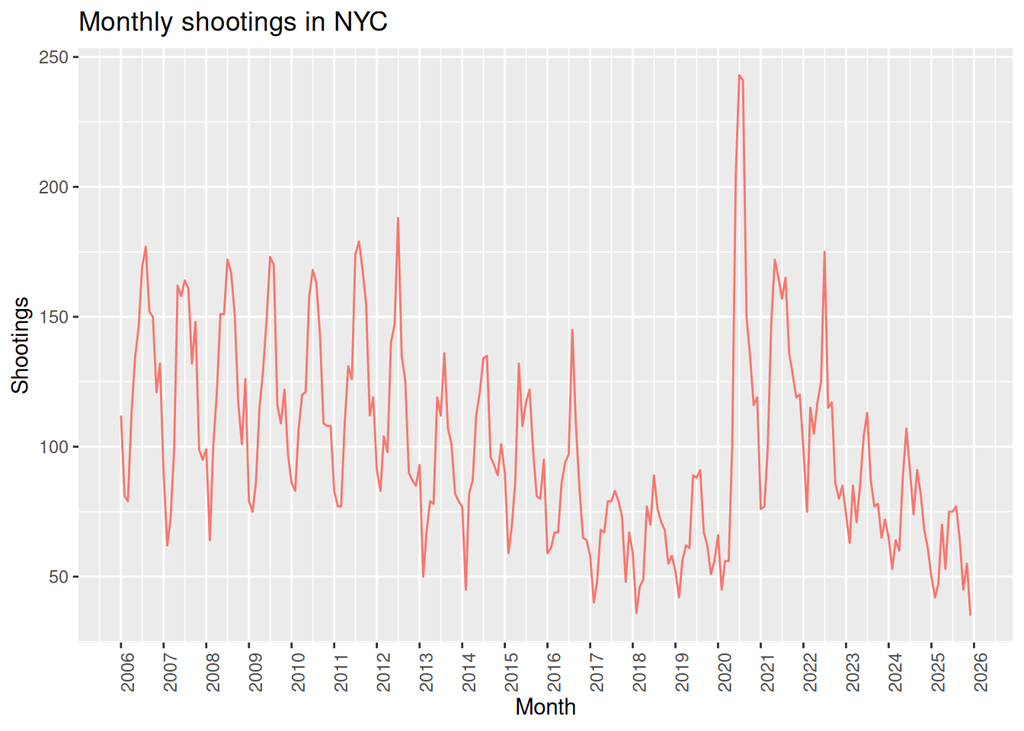

```r
shootings.by.month <- shootings.clean %>%
  group_by(Month = floor_date(Date, "month")) %>%
  summarise(Shootings = n())

shootings.by.month.plot <- shootings.by.month %>%
  ggplot(aes(x = Month, y = Shootings)) +
  geom_line(aes(color = 'red')) +
  scale_x_date(breaks = "year", date_labels = "%Y") +
  theme(legend.position = "none", axis.text.x = element_text(angle = 90)) +
  labs(title = "Monthly shootings in NYC")

plot(
  shootings.by.month.plot
)
```

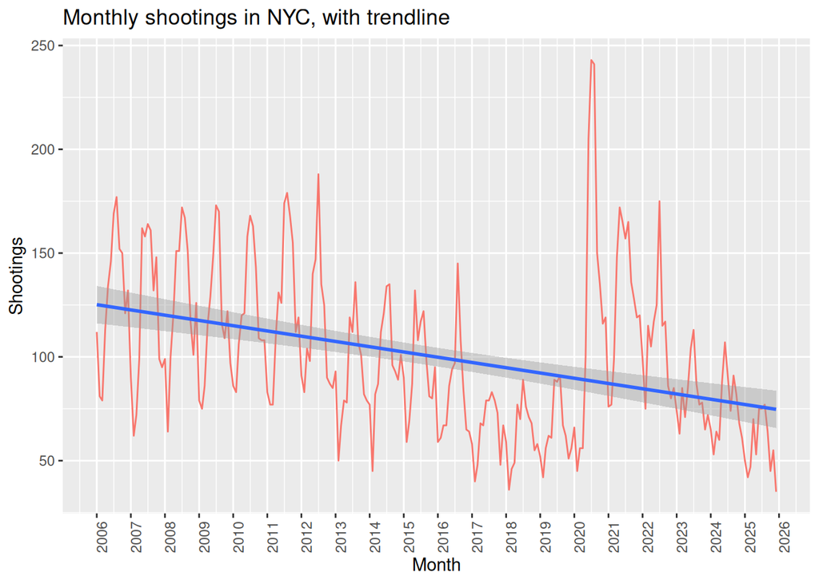

```r
shootings.by.month.trend.plot <- shootings.by.month %>%
  ggplot(aes(x = Month, y = Shootings)) +
  geom_line(aes(color = 'red')) +
  geom_smooth(method = "lm") +
  scale_x_date(breaks = "year", date_labels = "%Y") +
  theme(legend.position = "none", axis.text.x = element_text(angle = 90)) +
  labs(title = "Monthly shootings in NYC, with trendline")

plot(
  shootings.by.month.trend.plot
)
```

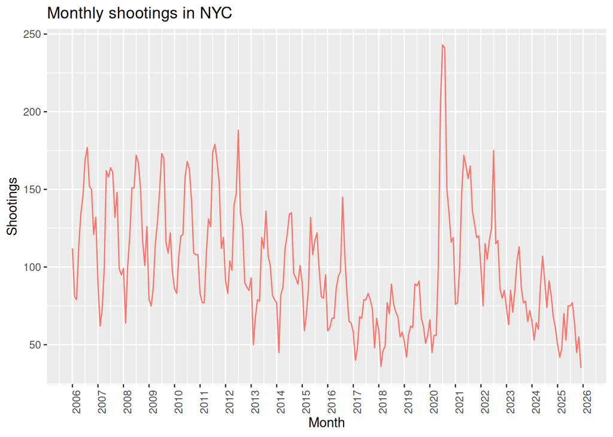

```r
shootings.seasonality.plot <- shootings.by.month %>%
  ggplot(aes(x = month(Month), y = Shootings, group = year(Month))) +
  geom_line(aes(color = 'red')) +
  scale_x_continuous(breaks = 1:12, labels = month.abb) +
  theme(legend.position = "none", axis.text.x = element_text(angle = 90)) +
  labs(title = "Seasonality of shootings in NYC", x = "Month")

plot(
  shootings.by.month.plot
)
```

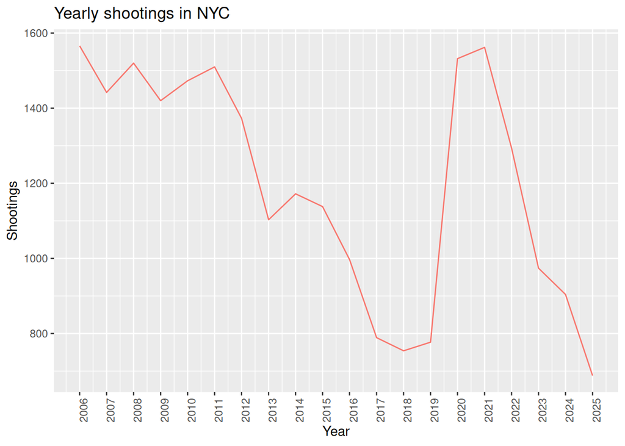

```r
shootings.by.year <- shootings.clean %>%
  group_by(Year = floor_date(Date, "year")) %>%
  summarise(Shootings = n()) %>%
  ungroup() %>%
  complete(Year, fill = list(Shootings = 0))

shootings.by.year.plot <- shootings.by.year %>%
  ggplot(aes(x = Year, y = Shootings)) +
  geom_line(aes(color = "red")) +
  scale_x_date(breaks = "year", date_labels = "%Y") +
  theme(legend.position = "none", axis.text.x = element_text(angle = 90)) +
  labs(title = "Yearly shootings in NYC")

plot(shootings.by.year.plot)
```

## Borough trends over time

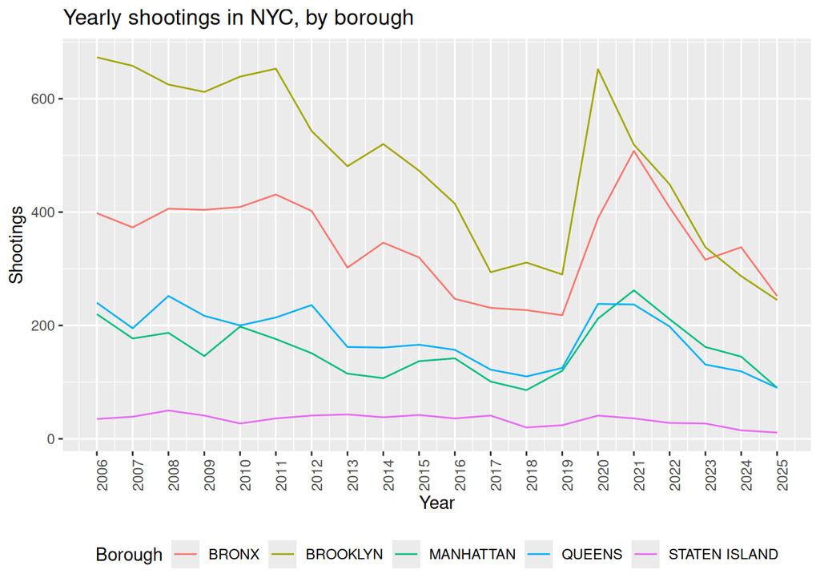

```r
shootings.by.year.and.borough <- shootings.clean %>%
  group_by(Year = floor_date(Date, "year"), Borough) %>%
  summarise(Shootings = n()) %>%
  ungroup() %>%
  complete(Year, Borough, fill = list(Shootings = 0))

shootings.by.year.and.borough.plot <- shootings.by.year.and.borough %>%
  ggplot(aes(x = Year, y = Shootings, group = Borough, color = Borough)) +
  geom_line() +
  scale_x_date(breaks = "year", date_labels = "%Y") +
  theme(legend.position = "bottom", axis.text.x = element_text(angle = 90)) +
  labs(title = "Yearly shootings in NYC, by borough")

plot(shootings.by.year.and.borough.plot)
```

## Where do shootings happen?

Mapping the shootings reveals that violence rates are quite distinct by precinct. Certain precincts have dramatically higher violence rates even than others within the same borough. These are grouped into 3 primary clusters: the largest in east Brooklyn, the next throughout most of The Bronx but crossing into north Manhattan, and the last in east Queens, around and to the north of JFK International Airport.

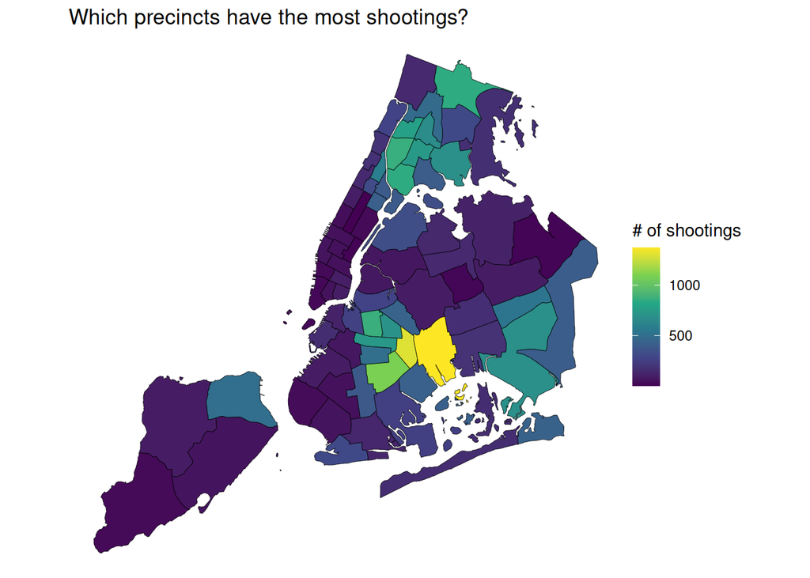

```r
# using Matt Herman's `nycgeo` package for map shapes: https://github.com/mfherman/nycgeo
library(nycgeo)
library(sf)

shootings.by.precinct <- shootings.clean %>%
  group_by(Precinct) %>%
  summarise(Shootings = n())

nyc.precincts <- nyc_boundaries(geography = "police")
st_crs(nyc.precincts) <- st_crs(nyc.precincts)

shootings.by.precinct.geo <- nyc.precincts %>%
  left_join(shootings.by.precinct, by = c("police_precinct_id" = "Precinct"))

shootings.by.precinct.plot <- shootings.by.precinct.geo %>%
  ggplot() +
  geom_sf(aes(fill = Shootings)) +
  scale_fill_viridis_c(name = "# of shootings") +
  theme_void() +
  labs(title = "Which precincts have the most shootings?")

plot(shootings.by.precinct.plot)
```

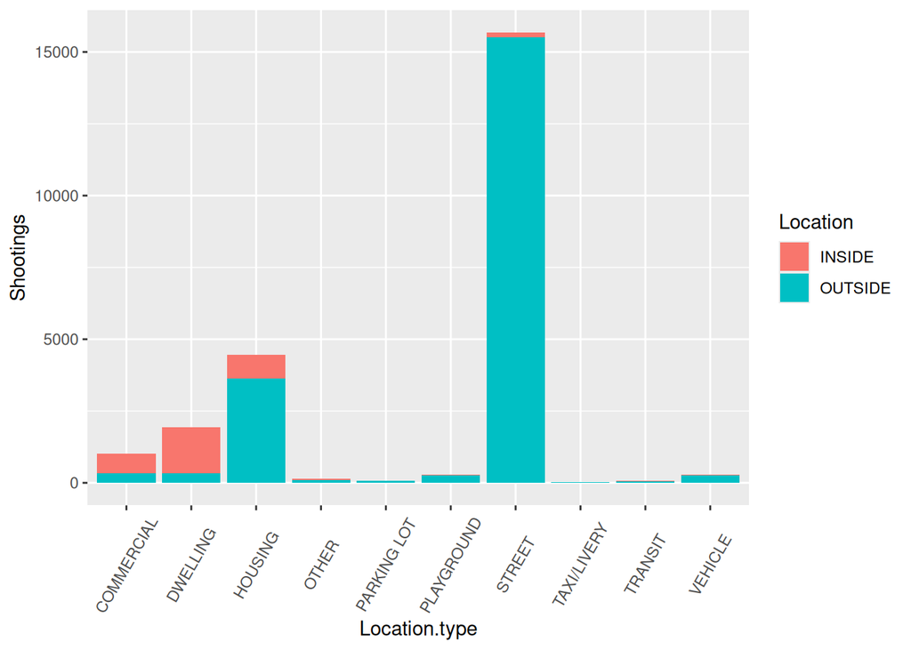

```r
shootings.by.location.type <- shootings.clean %>%
  drop_na(Location.type) %>%
  group_by(Location, Location.type) %>%
  summarise(Shootings = n())

shootings.by.location.type.plot <- shootings.by.location.type %>%
  ggplot(aes(y = Shootings, x = Location.type, fill = Location)) +
  geom_bar(stat='identity') +
  theme(axis.text.x = element_text(angle = 60, vjust = 0.5))

plot(shootings.by.location.type.plot)
```

## Modeling shootings

```r
shootings.for.model <- shootings.clean %>%
  group_by(Date = floor_date(Date, "month"), Borough) %>%
  summarise(Shootings = n()) %>%
  ungroup() %>%
  complete(Date, Borough, fill = list(Shootings = 0)) %>%
  mutate(
    Month = as.factor(month(Date)),
    Post.COVID.reopening = Date > "2020-06-01"
  )

model <- lm(Shootings ~ Date + Borough + Month + Post.COVID.reopening, data = shootings.for.model)
```

```r
# tidymodels makes a somewhat more legible display of results!
model.tidy <- tidy(model, conf.int = TRUE)
model.tidy
```

```
## # A tibble: 18 × 7
##    term                estimate std.error statistic   p.value conf.low conf.high
##    <chr>                  <dbl>     <dbl>     <dbl>     <dbl>    <dbl>     <dbl>
##  1 (Intercept)          7.43e+1  3.04        24.5   1.97e-107  6.84e+1  80.3
##  2 Date                -3.16e-3  0.000183   -17.3   6.92e- 60 -3.52e-3  -0.00280
##  3 BoroughBROOKLYN      1.15e+1  0.772       14.9   6.97e- 46  9.95e+0  13.0
##  4 BoroughMANHATTAN    -1.58e+1  0.772      -20.4   1.69e- 79 -1.73e+1 -14.2
##  5 BoroughQUEENS       -1.40e+1  0.772      -18.1   7.23e- 65 -1.55e+1 -12.5
##  6 BoroughSTATEN ISLA… -2.61e+1  0.772      -33.8   1.95e-175 -2.76e+1 -24.5
##  7 Month2              -3.35e+0  1.20        -2.80  5.15e-  3 -5.70e+0  -1.01
##  8 Month3              -1.43e-1  1.20        -0.119 9.05e-  1 -2.49e+0   2.20
##  9 Month4               2.55e+0  1.20         2.13  3.36e-  2  1.98e-1   4.89
## 10 Month5               6.76e+0  1.20         5.65  2.00e-  8  4.41e+0   9.11
## 11 Month6               9.86e+0  1.20         8.24  4.52e- 16  7.51e+0  12.2
## 12 Month7               1.22e+1  1.20        10.2   1.29e- 23  9.90e+0  14.6
## 13 Month8               1.16e+1  1.20         9.66  2.76e- 21  9.21e+0  13.9
## 14 Month9               7.14e+0  1.20         5.97  3.17e-  9  4.79e+0   9.49
## 15 Month10              4.69e+0  1.20         3.92  9.21e-  5  2.35e+0   7.04
## 16 Month11              2.08e+0  1.20         1.74  8.20e-  2 -2.65e-1   4.43
## 17 Month12              2.69e+0  1.20         2.25  2.49e-  2  3.40e-1   5.04
## 18 Post.COVID.reopeni…  1.06e+1  0.863       12.2   1.58e- 32  8.88e+0  12.3
```

## Plotting the model

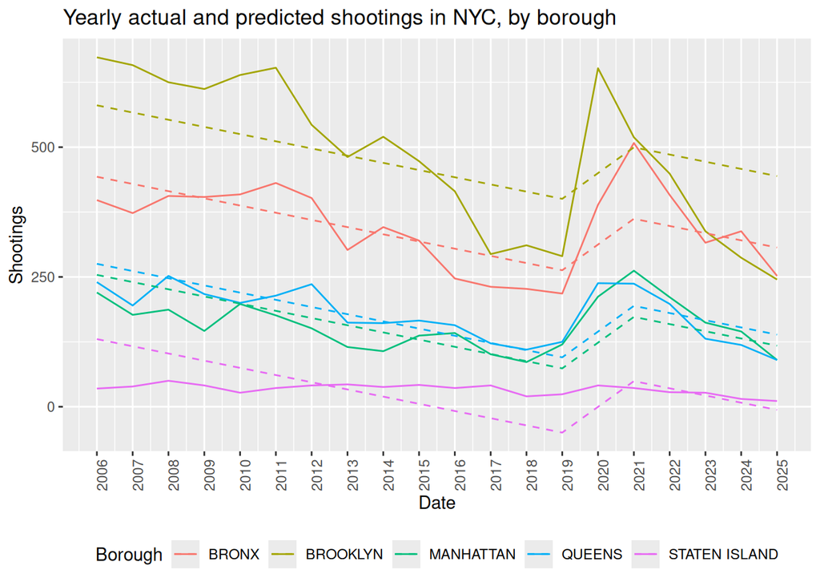

```r
shootings.with.preds <- shootings.for.model %>%
  mutate(
    Predicted = predict(model),
    Residual = Shootings - Predicted
  ) %>%
  group_by(Date = floor_date(Date, "year"), Borough) %>%
  summarise(
    Shootings = sum(Shootings),
    Predicted = sum(Predicted)
  ) %>%
  ungroup()


yearly.with.preds.plot <- shootings.with.preds %>%
  ggplot(aes(x = Date)) +
  geom_line(aes(x = Date, y = Shootings, group = Borough, color = Borough)) +
  geom_line(aes(x = Date, y = Predicted, group = Borough, color = Borough), linetype = "dashed") +
  scale_x_date(breaks = "year", date_labels = "%Y") +
  theme(legend.position = "bottom", axis.text.x = element_text(angle = 90)) +
  labs(title = "Yearly actual and predicted shootings in NYC, by borough")

plot(yearly.with.preds.plot)
```

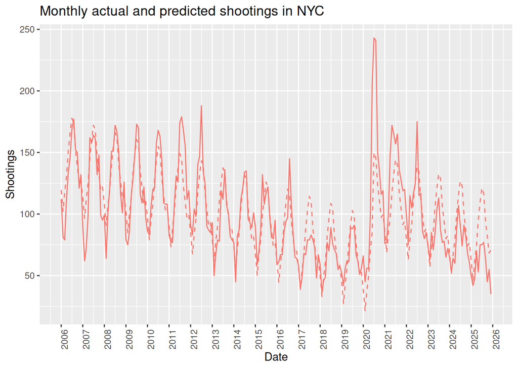

```r
shootings.with.preds <- shootings.for.model %>%
  mutate(
    Predicted = predict(model)
  ) %>%
  group_by(Date) %>%
  summarise(
    Shootings = sum(Shootings),
    Predicted = sum(Predicted),
    Residual = Shootings - Predicted
  ) %>%
  ungroup()


monthly.with.preds.plot <- shootings.with.preds %>%
  ggplot(aes(x = Date)) +
  geom_line(aes(x = Date, y = Shootings, color = "red")) +
  geom_line(aes(x = Date, y = Predicted, color = "red"), linetype = "dashed") +
  scale_x_date(breaks = "year", date_labels = "%Y") +
  theme(legend.position = "none", axis.text.x = element_text(angle = 90)) +
  labs(title = "Monthly actual and predicted shootings in NYC")

plot(monthly.with.preds.plot)
```

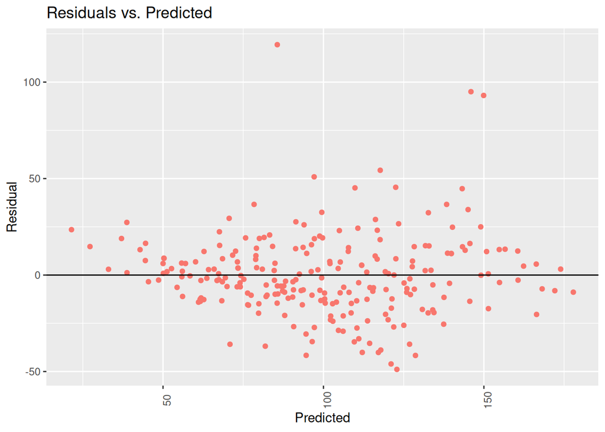

```r
shootings.with.preds %>%
  ggplot() +
  geom_point(aes(x = Predicted, y = Residual, color = "red")) +
  geom_hline(yintercept = 0) +
  theme(legend.position = "none", axis.text.x = element_text(angle = 90)) +
  labs(title = "Residuals vs. Predicted")
```

## Potential sources of bias

There are definitely some potential sources of bias:

- This analysis is raw totals, not per-capita data. This could make very populous areas look more violent than they really are.
- The analyst might focus too much on locations that have negative media attention, or on locations that they personally are anxious about.
- It is possible that shootings could go underreported in areas that have lower average police presence or lower trust in policing.
- It is possible that the 2006 cutoff for the beginning of the dataset hides trends that would be obvious on a longer time horizon.
- It is possible that looking only at the occurrence of a shooting, and not at demographic or socioeconomic information, might hide underlying trends